# PART B: RECURRENT NEURAL NETWORK

## Preparing the required libraries

```python
# Helper libraries
import pandas as pd
import pandas as pd
import seaborn as sns
import matplotlib.pyplot as plt
import numpy as np
import tensorflow as tf
import warnings
warnings.filterwarnings('ignore')

# For EDA
import nltk
nltk.download('stopwords')
from wordcloud import WordCloud
from nltk.corpus import stopwords
from collections import Counter

# Preprocessing
from tensorflow.keras.preprocessing.sequence import pad_sequences
from deep_translator import GoogleTranslator

# For model building
from sklearn.model_selection import train_test_split
from tensorflow.keras.models import Sequential
from tensorflow.keras.layers import Embedding, SimpleRNN, Dense, LSTM, GRU, Dropout, Bidirectional, SpatialDropout1D
from tensorflow.keras.callbacks import EarlyStopping

# For tuning
from sklearn.metrics import accuracy_score
from sklearn.model_selection import RandomizedSearchCV
from tensorflow.keras.wrappers.scikit_learn import KerasClassifier
from tensorflow.keras.optimizers import Adam
from tensorflow.keras.callbacks import EarlyStopping


# Tokenizer
from tensorflow.keras.preprocessing.text import Tokenizer
```

## Background research

The primary goal in DELE CA1 Part B is to develop a movie review analyser using a deep learning network capable of accurately classifying movie reviews into negative/positive labels through classification or conduct movie review prediction through regression.

The challenge lies in creating a comprehensive model that can differentiate between positive or negative reviews for classification or prediciting the next word of a review for regression. Achieving accurate classification/regression involves the use text sentiment analysis and machine learning.

In this context of movie review, we would be doing classification, where our focus is to train on a diverse dataset comprising of 4 different languages ranging from postive to negative reviews.

## EDA

### Head and tail of dataset

```python
# Loading the movie reviews dataset for eda
data_eda = pd.read_csv('Movie reviews.csv')
```

```python
# Display the first few rows of the dataframe
data_eda.head(5)
```

|  | Review | Score | Are there ways for you to generate more data? Spliting up sentences, would that help? | Language |
| --- | --- | --- | --- | --- |
| 0 | Filem ini hebat! Aksi yang mendebarkan dan plo... | 0.1 | NaN | Malay |
| 1 | Filem ini hebat! Aksi yang mendebarkan dan plo... | 0.9 | NaN | Malay |
| 2 | Filem ini hebat! Aksi yang mendebarkan dan plo... | 0.5 | NaN | Malay |
| 3 | Sayang sekali, pelakon tidak memberikan persem... | 0.8 | NaN | Malay |
| 4 | Jalan cerita yang kompleks dan penuh emosi. Su... | 0.2 | NaN | Malay |

```python
# Display the last few rows of the dataframe
data_eda.tail(5)
```

|  | Review | Score | Are there ways for you to generate more data? Spliting up sentences, would that help? | Language |
| --- | --- | --- | --- | --- |
| 522 | Pening | 0.7 | NaN | Malay |
| 523 | Berkesan | 0.2 | NaN | Malay |
| 524 | Mengujakan | 0.1 | NaN | Malay |
| 525 | Sederhana and teruk | 0.6 | NaN | Malay |
| 526 | Sempurna | 0.1 | NaN | Malay |

From above, we can see the first 5 rows and last 5 rows to get the general structure of the dataset.

### Shape of dataset

```python
# Check the shape of the dataframe
print(data_eda.shape)
```

```
(527, 4)
```

This shows that there is 527 reviews and 4 columns in the dataset.

### Column names of dataset

```python
print(data_eda.columns.tolist())
```

```
['Review', 'Score', 'Are there ways for you to generate more data? Spliting up sentences, would that help?', 'Language']
```

From above, we can see the names of the 4 columns in the dataset.

### Statistics of languages in the dataset

```python
# Prints the number of unique lanugages
num_languages = data_eda['Language'].nunique()
print("Number of unique languages:", num_languages)

# Prints the number of each unique language
language_counts = data_eda['Language'].value_counts()
print(language_counts)
```

```
Number of unique languages: 4
Language
English    298
Malay      226
Chinese      2
Nippon       1
Name: count, dtype: int64
```

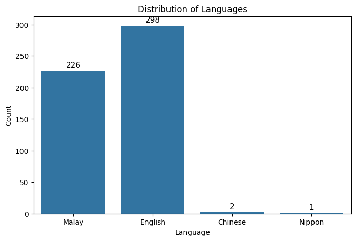

```python
# Assuming 'data_eda' is your DataFrame and 'Language' is the column of interest
plt.figure(figsize=(8, 5))
ax = sns.countplot(x='Language', data=data_eda)

# Add numbers to the top of the bars
for p in ax.patches:
    ax.annotate(f'{int(p.get_height())}',
                (p.get_x() + p.get_width() / 2., p.get_height()),
                ha='center', va='baseline',
                fontsize=11, color='black', xytext=(0, 5),
                textcoords='offset points')

plt.title('Distribution of Languages')
plt.xlabel('Language')
plt.ylabel('Count')
plt.show()
```

This shows the visualisation of the distribution of languages. We can see that English has the most reviews, followed by Malay and Chinese then Nippon.

### Statstics of scores in the dataset

```python
# Summary statistics
data_eda['Score'].describe()
```

```
count    525.000000
mean       0.282626
std        0.263022
min        0.001000
25%        0.100000
50%        0.120000
75%        0.500000
max        0.997413
Name: Score, dtype: float64
```

This shows the basic statistics of the score table.

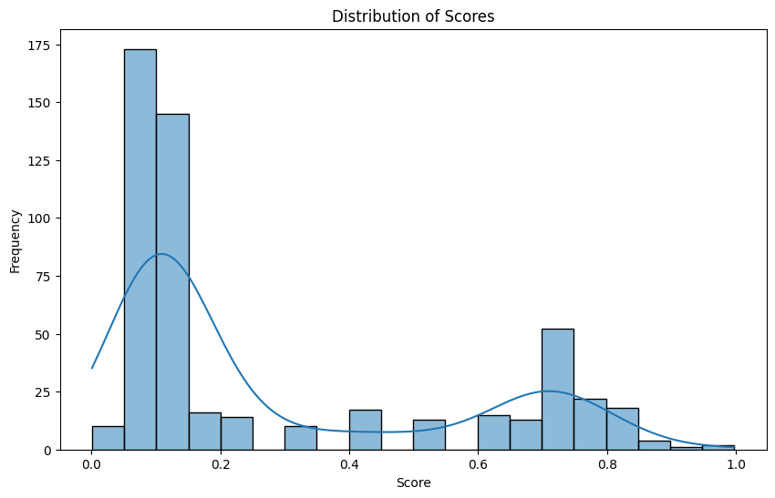

```python
# Distribution of scores
plt.figure(figsize=(10, 6))
sns.histplot(data_eda['Score'], bins=20, kde=True)
plt.title('Distribution of Scores')
plt.xlabel('Score')
plt.ylabel('Frequency')
plt.show()
```

This shows the visualisation of the distribution of scores. We can see that there is a larger number of reviews between 0 and 0.2.

```python
# Filter reviews by English language for analysing purposes as I am not able to understand any other languages
df_english = data_eda[data_eda['Language'] == 'English']

# Sort by score
df_sorted_eda = df_english.sort_values(by='Score')

# Get first 10 and last 10 reviews
first_10_reviews = df_sorted_eda.head(10)
last_10_reviews = df_sorted_eda.tail(10)

# Print the first 10 reviews
print("First 10 Reviews by Score:")
print(first_10_reviews[['Review', 'Score']])

print("\nLast 10 Reviews by Score:")
print(last_10_reviews[['Review', 'Score']])
```

```
First 10 Reviews by Score:
                                                Review  Score
263  The visual effects and animation in this film ...   0.05
209  This movie delivers an outstanding experience....   0.05
400                                        Masterpiece   0.05
496                             Masterful storytelling   0.05
264  This film is a masterpiece! The storytelling i...   0.05
320  Avengers: Endgame is an absolute masterpiece! ...   0.05
382  The film's pacing is a testament to its storyt...   0.06
386  Avengers: Endgame's pacing is a triumph, seaml...   0.06
352  Avengers: Endgame is a cinematic triumph, seam...   0.06
399  The film's pacing is a testament to its storyt...   0.06

Last 10 Reviews by Score:
                                                Review  Score
486                                Unconvincing acting   0.75
333  While the main actors deliver commendable perf...   0.75
294  This film is highly disappointing. It fails to...   0.80
472                           Disappointing resolution   0.80
219  I'm not satisfied with how the main actors del...   0.80
262  Lack of character development makes this film ...   0.80
430                                      Disappointing   0.80
236  This film is very disappointing. Not worth the...   0.80
212  Avengers: Endgame is disappointing and too cli...   0.85
493                                           Diabolic    NaN
```

From above, we can see that the scores show how positive/negative the review of the movie would be. This means that the larger the score of the review, the more negative the review would be. On the other hand, the smaller the score of the review, the more positive the review would be. Combined with the fact that there is a larger number of reviews with a score of 0 to 0.2, it shows that there are more positive reviews than compared with the negative reviews in the dataset.

### Checking of missing values in the dataset

```python
# Check for missing values
print(data_eda.isnull().sum())

# Find rows with NaN scores, excluding the third column
nan_scores = data_eda.loc[data_eda['Score'].isnull(), data_eda.columns.difference(['Are there ways for you to generate more data? Spliting up sentences, would that help?'])]

# Print the rows with NaN scores, excluding the third column because it is all NaN values
print(nan_scores)
```

```
Review                                                                                     0
Score                                                                                      2
Are there ways for you to generate more data? Spliting up sentences, would that help?    527
Language                                                                                   0
dtype: int64
    Language    Review  Score
426  Chinese    Ni hao    NaN
493  English  Diabolic    NaN
```

From above, we can see that there is 527 NaN values in the "Are there ways for you to generate more data? Spliting up sentences, would that help?" column and that there is 2 NaN values in the "Score" column.

The 2 NaN values from the score column come from the reviews 'Ni Hao' which is Chinese language and 'Diabloic' which is English language.

### Analysis of sentences/words in the dataset

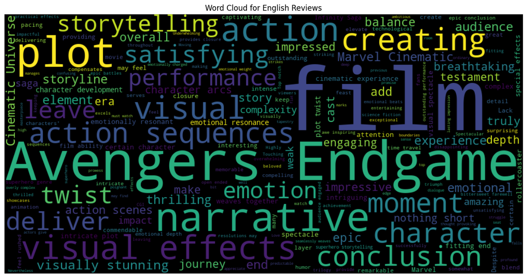

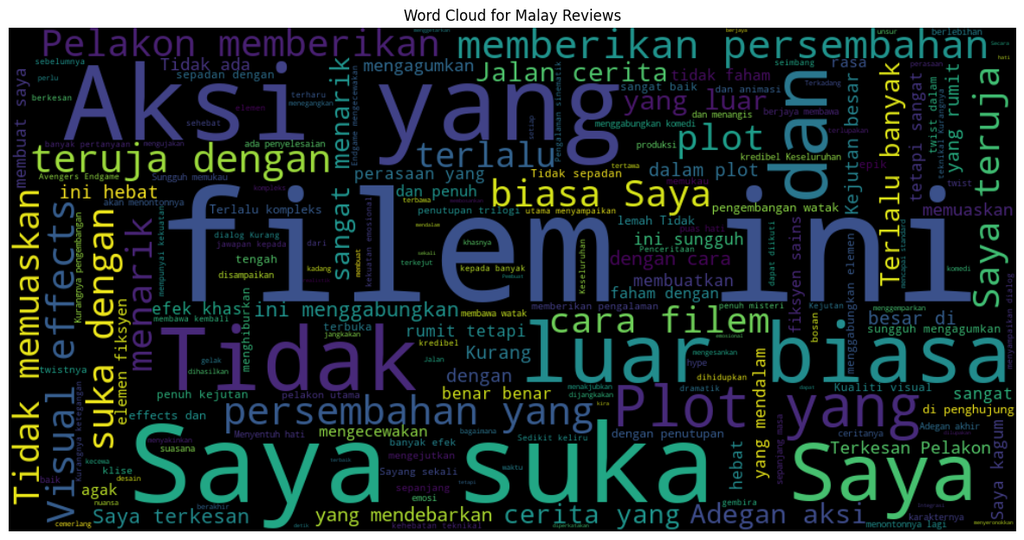

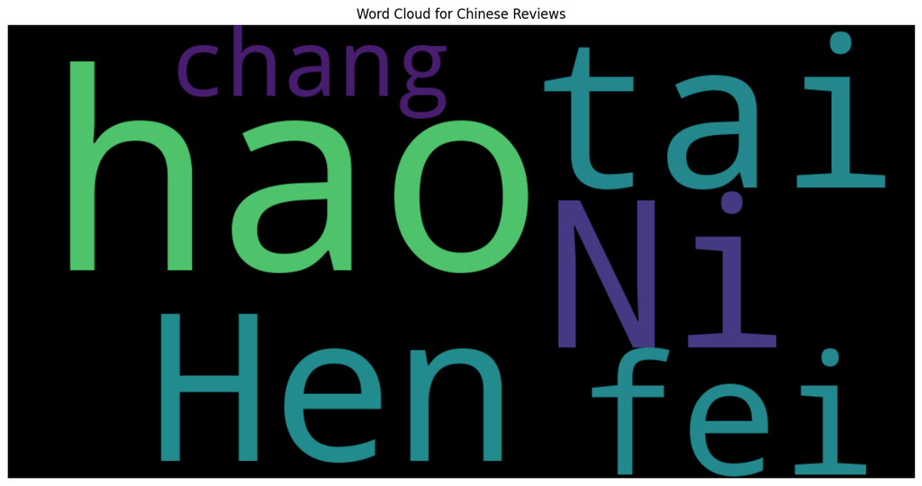

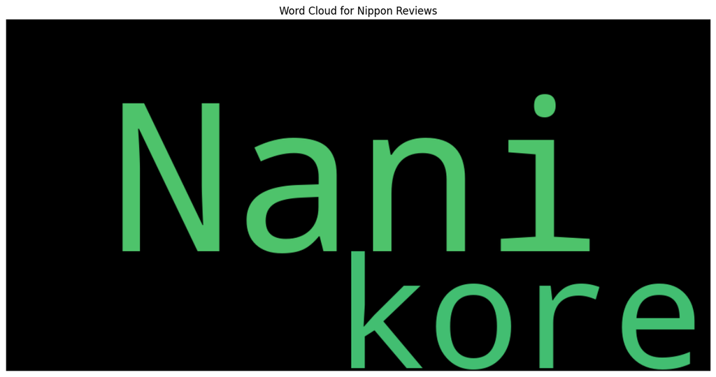

```python
# List of languages
languages = ['English', 'Malay', 'Chinese', 'Nippon']

for lang in languages:
    # Filter reviews of the current language
    reviews = data_eda[data_eda['Language'] == lang]['Review']

    # Combine all reviews into one large string
    text = ' '.join(reviews)

    # Create a word cloud
    wordcloud = WordCloud(width = 1000, height = 500).generate(text)

    # Display the word cloud
    plt.figure(figsize=(15,8))
    plt.imshow(wordcloud, interpolation='bilinear')
    plt.title(f'Word Cloud for {lang} Reviews')
    plt.axis("off")
    plt.show()
```

From the above Wordcloud, we are able to easily see which words are used more often than others.

Observations:

- We can see how the most common words are Avengers Endgame, film, plot, narrative, visual effects which are all used for describing a movie which is to be expected in a review.
- For other langauge such as Malay, one can expect the same since I do not speak Malay.
- As seen in previous analysis, there is limited number of reviews in the languages Chinese and Nippon. This would affect the common words in the wordcloud in this case as there would not be enough words to take from which led to the case as shown above.

```python
# Group the data by 'Review' and get all scores for each review
grouped = data_eda.groupby('Review')['Score'].apply(list)

# Initialize a counter for duplicated reviews
duplicate_count = 0

# Find and print all the duplicates
for review, scores in grouped.items():
    if len(scores) > 1:
        duplicate_count += 1
        print(f"Review: {review}")
        print(f"Scores: {scores}")
        print(f"Count: {len(scores)}")
        print()

# Print the number of duplicated reviews
print(f"Number of duplicated reviews: {duplicate_count}")
```

```
Review: Adegan akhir yang sangat epik! Saya teruja dengan penutupan trilogi ini.
Scores: [0.08, 0.08, 0.08]
Count: 3

Review: Adegan aksi yang luar biasa. Saya rasa teruja sepanjang masa.
Scores: [0.12, 0.12]
Count: 2

Review: Adegan aksi yang luar biasa. Teruja dengan penutupan trilogi ini.
Scores: [0.12, 0.12]
Count: 2

Review: Adegan aksi yang terlalu berlebihan. Terlalu banyak efek khas.
Scores: [0.6, 0.6, 0.6]
Count: 3

Review: Aksi yang mendebarkan tetapi plot agak lemah. Tidak seimbang.
Scores: [0.5, 0.5, 0.5]
Count: 3

Review: Aksi yang menegangkan sepanjang filem. Saya teruja!
Scores: [0.12, 0.12]
Count: 2

Review: Avengers: Endgame's CGI and practical effects work in harmony, creating a visually stunning cinematic experience. The attention to detail in the visual effects enhances the film's overall impact. A testament to the technological achievements in modern filmmaking.
Scores: [0.08, 0.08]
Count: 2

Review: Avengers: Endgame's action sequences are a feast for the eyes, with every punch and explosion meticulously choreographed. The film's attention to detail, especially in the visual effects, elevates the viewing experience. A thrilling and visually stunning conclusion to the Marvel Cinematic Un…
Scores: [0.08, 0.08]
Count: 2

Review: Avengers: Endgame's pacing is a triumph, seamlessly transitioning between high-octane action and character-driven moments. The film's ability to evoke laughter and tears showcases its versatility. A remarkable achievement in cinematic storytelling.
Scores: [0.06, 0.06]
Count: 2

Review: Avengers: Endgame's visual effects are a technological marvel, pushing the boundaries of what can be achieved in cinema. The film's meticulous attention to detail, especially in the action sequences, showcases the dedication of the filmmaking team. A visual spectacle that leaves a lasting im…
Scores: [0.08, 0.08]
Count: 2

```

[output cut: 310 more lines]

```
Count: 2

Review: While Avengers: Endgame provides closure to some storylines, certain character arcs feel underdeveloped. The film, however, compensates with epic battles and stunning visuals. A rollercoaster of emotions that serves as a fitting end to an era of superhero storytelling.
Scores: [0.4, 0.4]
Count: 2

Review: While the film delivers on emotional beats, certain character resolutions may feel rushed. Avengers: Endgame, however, excels in creating epic and memorable action sequences. A rollercoaster of emotions that serves as a fitting end to the Infinity Saga.
Scores: [0.25, 0.25]
Count: 2

Review: While the film provides closure to some character arcs, certain plot points are left unresolved, leaving room for future exploration. Avengers: Endgame, however, excels in delivering awe-inspiring action and emotional resonance. A bittersweet farewell to an era of superhero storytelling.
Scores: [0.3, 0.3]
Count: 2

Number of duplicated reviews: 91
```

From above, we can see that there are duplicated reviews. It is also important to note that while most of the duplicated reviews have the same scores, there are some reviews that have different scores even if the sentence is duplicated exactly.

```
Minimum number of words in English: 1
Maximum number of words in English: 57
```

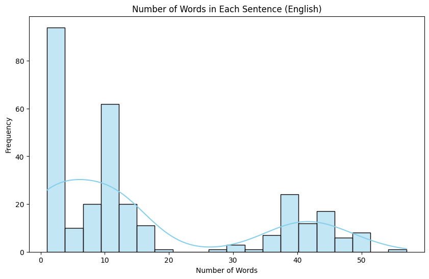

```
Minimum number of words in Malay: 1
Maximum number of words in Malay: 12
```

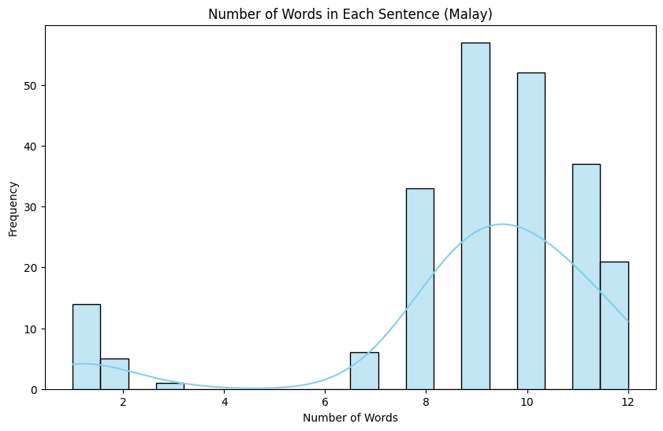

```
Minimum number of words in Chinese: 2
Maximum number of words in Chinese: 5
```

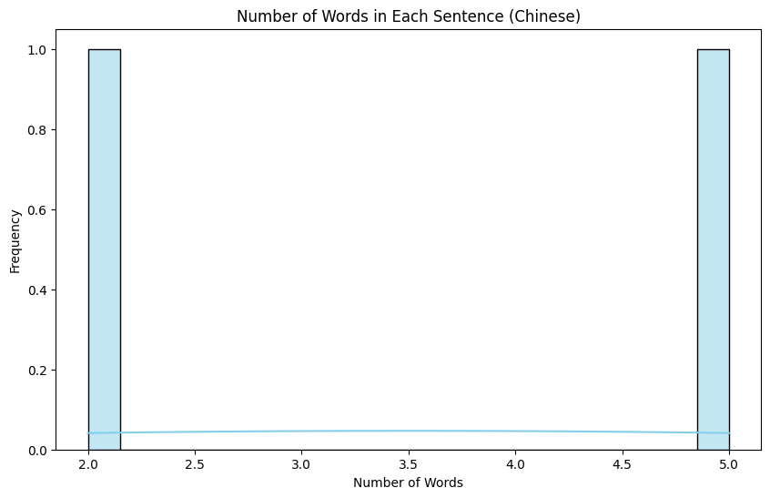

```
Minimum number of words in Nippon: 2
Maximum number of words in Nippon: 2
```

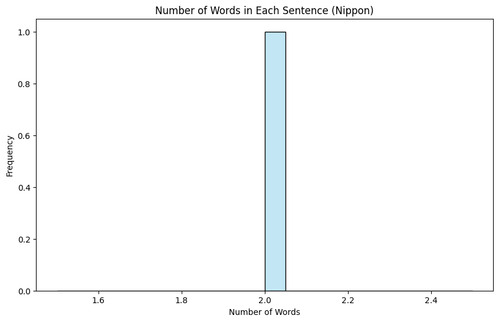

```python
# Function to process each language separately
def process_language(data, language):
    # Filter reviews by language
    lang_data = data[data['Language'] == language]

    # Calculate word count for each review
    lang_data['Word Count'] = lang_data['Review'].apply(lambda x: len(x.split()))

    # Calculate minimum and maximum word counts
    min_word_count = lang_data['Word Count'].min()
    max_word_count = lang_data['Word Count'].max()

    # Print the minimum and maximum number of words
    print(f"Minimum number of words in {language}: {min_word_count}")
    print(f"Maximum number of words in {language}: {max_word_count}")

    # Plot histogram with density curve
    plt.figure(figsize=(10, 6))
    sns.histplot(lang_data['Word Count'], bins=20, kde=True, color='skyblue')
    plt.title(f'Number of Words in Each Sentence ({language})')
    plt.xlabel('Number of Words')
    plt.ylabel('Frequency')
    plt.show()

# List of languages to process
languages = ['English', 'Malay', 'Chinese', 'Nippon']

# Apply the function to each language
for language in languages:
    process_language(data_eda, language)
```

From above, we can see:

Chinese:

- The minimum number of words in a review in the dataset is 2 and the maximum number of words in a sentence is 5.
- This is due to the limited number of reviews in the dataset with the language.

Nippon:

- The minimum number of words in a review in the dataset is 2 and the maximum number of words in a sentence is 2.
- This is due to the limited number of reviews in the dataset with the language.

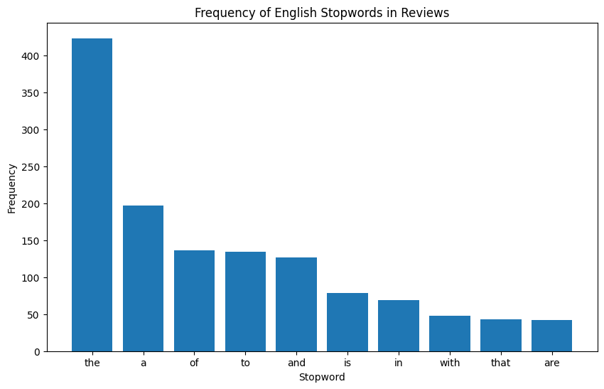

```python
# Define English stopwords
stop_words = set(stopwords.words('english'))

# Initialize a Counter object
counter = Counter()

# Update the counter for each review
for review in data_eda['Review']:
    words = review.split()
    counter.update(word.lower() for word in words if word.lower() in stop_words)

# Get the most common stopwords
common_stopwords = counter.most_common(10)

# Create a bar chart
plt.figure(figsize=(10,6))
plt.bar(*zip(*common_stopwords))
plt.title('Frequency of English Stopwords in Reviews')
plt.xlabel('Stopword')
plt.ylabel('Frequency')
plt.show()
```

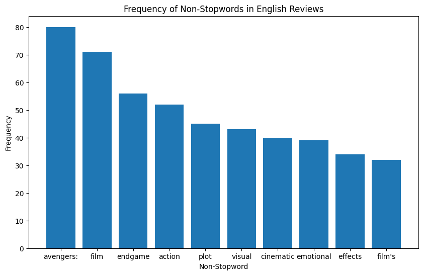

```python
# Filter English reviews
english_reviews = data_eda[data_eda['Language'] == 'English']['Review']

# Initialize a Counter object
counter = Counter()

# Update the counter for each English review
for review in english_reviews:
    words = review.split()
    counter.update(word.lower() for word in words if word.lower() not in stop_words)

# Get the most common non-stopwords
common_non_stopwords = counter.most_common(10)

# Create a bar chart
plt.figure(figsize=(10,6))
plt.bar(*zip(*common_non_stopwords))
plt.title('Frequency of Non-Stopwords in English Reviews')
plt.xlabel('Non-Stopword')
plt.ylabel('Frequency')
plt.show()
```

Stopwords are commonly occurring words in a language that are often considered to carry little or no significant meaning in the context of natural language processing (NLP) tasks such as text analysis, search engines, or machine learning models. These words are typically filtered out because they occur frequently across documents and don't contribute much to the understanding or differentiation of the documents. Examples of stopwords in English in this case include "the," "a," "of," "to," etc.

On the other hand, "non-stop words" refer to all the words in a document or a corpus that are not stopwords. These words carry the primary semantic content and meaning in the text and are typically what we're interested in when performing NLP tasks. Non-stop words can include nouns, verbs, adjectives, adverbs, and other content-bearing words that convey the main message or information in a piece of text.

In summary, stopwords are words that are filtered out during text processing because they are common and carry little meaning, while non-stop words are the remaining words in the text that convey the main semantic content and are of interest for analysis.

Analyzing the amount and the types of stopwords can give us some good insights into the data.

## Preprocessing/Feature Engineering

### Loading the dataset

```python
# Loading the movie reviews dataset
data = pd.read_csv('Movie reviews.csv')
```

### Attempting to add in more training data

Generating more training data for recurrent neural networks (RNNs) can be beneficial for improving the model's performance and generalization. Here are some reasons why generating more training data could be useful:

- Improved Generalization: More training data can help the model learn a more robust representation of the underlying patterns in the data. This can lead to better generalization performance on unseen data, reducing overfitting.
- Capturing Diverse Patterns: Additional training data can help capture a wider range of patterns and variations present in the dataset. This is particularly important in tasks where the input data may have diverse characteristics or contexts.
- Handling Rare Events: Rare events or edge cases may not be adequately represented in the original training data. Generating more data, especially by augmenting existing data or introducing variations, can help the model learn to handle these cases more effectively.
- Data Balancing: In classification tasks with imbalanced classes, generating synthetic data for minority classes can help balance the dataset. This prevents the model from being biased towards the majority class and improves its ability to recognize minority class instances.
- Data Augmentation: Techniques such as adding noise, rotating, scaling, or cropping input data can effectively augment the dataset, providing the model with more variations of the same data instances. This helps the model become more invariant to small changes in the input.

```python
# Initialize an empty list to store translated reviews
translated_reviews = []

# Translate Malay reviews to English and add to the list
for index, row in data.iterrows():
    if row['Language'] == 'Malay':
        translated_review = GoogleTranslator(source='auto', target='en').translate(row['Review'])
        translated_reviews.append({'Original Review': row['Review'],
                                   'Translated Review': translated_review,
                                   'Score': row['Score']})

# Create a DataFrame from the list of translated reviews
translated_data = pd.DataFrame(translated_reviews)

# Display the translated data table
print(translated_data)
# Add English reviews and their associated scores from the original dataset
for index, row in data.iterrows():
    if row['Language'] != 'Malay':
        translated_reviews.append({'Original Review': row['Review'],
                                   'Translated Review': row['Review'],
                                   'Score': row['Score']})

# Create a DataFrame from the list of translated reviews
translated_data = pd.DataFrame(translated_reviews)

# Display the translated data table
print(translated_data)
```

```
                                       Original Review  \
0    Filem ini hebat! Aksi yang mendebarkan dan plo...
1    Filem ini hebat! Aksi yang mendebarkan dan plo...
2    Filem ini hebat! Aksi yang mendebarkan dan plo...
3    Sayang sekali, pelakon tidak memberikan persem...
4    Jalan cerita yang kompleks dan penuh emosi. Su...
..                                                 ...
221                                             Pening
222                                           Berkesan
223                                         Mengujakan
224                                Sederhana and teruk
225                                           Sempurna

                                     Translated Review  Score
0    This movie is great! Thrilling action and a su...    0.1
```

[output cut: 39 more lines]

We have just translated the Malay reviews into English and then added the existing English reviews into the translated dataset to be used for future training.

### Removing of NaN values

```python
# Dropping the NaN scores
data_cleaned = data.dropna(subset=['Score'])

# Drop the third column
data_cleaned = data_cleaned.drop(columns=['Are there ways for you to generate more data? Spliting up sentences, would that help?'])

# Check for missing values again
print(data_cleaned.isnull().sum())
```

```
Review      0
Score       0
Language    0
dtype: int64
```

We have dropped the reviews with NaN score values.

### Filter English to ensure only reviews is used

```python
# Filtering out english language only
english_data =  data_cleaned[data_cleaned['Language'] == 'English']

# Display the filtered dataset
print(english_data)
```

```
                                                Review  Score Language
206  This movie is amazing! The action is breathtak...   0.08  English
207  I'm disappointed with the actors' performance....   0.70  English
208  The storyline is touching and full of emotion....   0.12  English
209  This movie delivers an outstanding experience....   0.05  English
210  Too many action scenes, sometimes unnecessary....   0.40  English
..                                                 ...    ...      ...
502         Compelling story, outstanding performances   0.12  English
503                  Intricate plot, unexpected twists   0.10  English
504      Underwhelming moments, weak characterizations   0.60  English
505           Breathtaking visuals, engaging narrative   0.08  English
506        Top-notch effects, captivating storytelling   0.08  English

[297 rows x 3 columns]
```

Decision on which languages to use:

- Focus on English Only:
  - Considering only English reviews simplifies the problem. We can leverage pre-trained embeddings (like Word2Vec, GloVe, or BERT) specific to English, which are more robust and widely available. This approach avoids complications arising from multilingual text processing, such as language detection, translation, and handling different vocabularies.
- Multilingual Approach:
  - If we aim to include reviews in multiple languages, we need to preprocess the data to identify the language of each review and potentially use multilingual embeddings (like mBERT) or translation services to unify the dataset into a single language. This approach is more complex but can provide a more comprehensive analysis.

For this task, we will focus on English reviews only. This decision is based on the following reasons:

- Simplifies data preprocessing.
- Easier to leverage English-specific models and embeddings.
- More training data available in English, leading to better model performance.
- I also only can read English so it would be more reliable for verification.
- The Chinese and Nippon reviews are too little in numbers so using them would not be effective and be biased.

### Tokenizing the reviews

```python
X = list(english_data.Review.values)
y = english_data['Score'].values

tokenizer = Tokenizer()
tokenizer.fit_on_texts(X)
print(tokenizer.word_index)

total_words = len(tokenizer.word_index)
print('Total number of token words:' , total_words)

# Convert text to sequences for each review
X_sequences = tokenizer.texts_to_sequences(X)

# Print the original text and corresponding token sequences for each review
for i, review in enumerate(X):
    print("Review", i+1, ":")
    print("Original Review:")
    print(review)
    print("Tokenized Sequence:")
    print(X_sequences[i])
    print()
```

```
{'the': 1, 'a': 2, 'of': 3, 'to': 4, 'and': 5, 'film': 6, 'avengers': 7, 'is': 8, 'in': 9, 'action': 10, 'plot': 11, 'endgame': 12, 'with': 13, 'this': 14, 'that': 15, 'visual': 16, 'effects': 17, 'are': 18, 'cinematic': 19, 'narrative': 20, 'emotional': 21, 'character': 22, "film's": 23, 'an': 24, …
Total number of token words: 737
Review 1 :
Original Review:
This movie is amazing! The action is breathtaking, and the plot is intriguing.
Tokenized Sequence:
[14, 167, 8, 95, 1, 10, 8, 74, 5, 1, 11, 8, 107]

Review 2 :
Original Review:
I'm disappointed with the actors' performance. Not satisfying.
Tokenized Sequence:
[50, 482, 13, 1, 277, 214, 66, 46]

Review 3 :
Original Review:
The storyline is touching and full of emotion. I love it!
Tokenized Sequence:
[1, 126, 8, 168, 5, 350, 3, 215, 28, 216, 36]

Review 4 :
Original Review:
This movie delivers an outstanding experience. Truly captivating!
Tokenized Sequence:
[14, 167, 59, 24, 67, 32, 75, 127]

Review 5 :
Original Review:
Too many action scenes, sometimes unnecessary. Too dramatic.
Tokenized Sequence:
[84, 128, 10, 55, 483, 484, 84, 351]

Review 6 :
Original Review:
I'm thrilled throughout the movie. Engaging storytelling!
Tokenized Sequence:
[50, 169, 170, 1, 167, 85, 37]

Review 7 :
Original Review:
```

[output cut: 1728 more lines]

```
Underwhelming moments, weak characterizations
Tokenized Sequence:
[248, 31, 98, 481]

Review 296 :
Original Review:
Breathtaking visuals, engaging narrative
Tokenized Sequence:
[74, 62, 85, 20]

Review 297 :
Original Review:
Top-notch effects, captivating storytelling
Tokenized Sequence:
[110, 185, 17, 127, 37]
```

```python
# Perform sequence padding
# You can specify `maxlen` to set a maximum length for sequences if desired
max_sequence_length = max(len(seq) for seq in X_sequences)  # Maximum length of sequences in the dataset
X_padded = pad_sequences(X_sequences, maxlen=max_sequence_length, padding='post')

# Print the padded sequences for each review
for i, review in enumerate(X):
    print("Review", i+1, ":")
    print("Original Review:")
    print(review)
    print("Padded Sequence:")
    print(X_padded[i])
    print()

print("Padded sequences shape:", X_padded.shape)
```

```
Review 1 :
Original Review:
This movie is amazing! The action is breathtaking, and the plot is intriguing.
Padded Sequence:
[ 14 167   8  95   1  10   8  74   5   1  11   8 107   0   0   0   0   0
   0   0   0   0   0   0   0   0   0   0   0   0   0   0   0   0   0   0
   0   0   0   0   0   0   0   0   0   0   0   0   0   0   0   0   0   0
   0   0   0]

Review 2 :
Original Review:
I'm disappointed with the actors' performance. Not satisfying.
Padded Sequence:
[ 50 482  13   1 277 214  66  46   0   0   0   0   0   0   0   0   0   0
   0   0   0   0   0   0   0   0   0   0   0   0   0   0   0   0   0   0
   0   0   0   0   0   0   0   0   0   0   0   0   0   0   0   0   0   0
   0   0   0]

Review 3 :
Original Review:
The storyline is touching and full of emotion. I love it!
Padded Sequence:
[  1 126   8 168   5 350   3 215  28 216  36   0   0   0   0   0   0   0
   0   0   0   0   0   0   0   0   0   0   0   0   0   0   0   0   0   0
   0   0   0   0   0   0   0   0   0   0   0   0   0   0   0   0   0   0
   0   0   0]

Review 4 :
Original Review:
This movie delivers an outstanding experience. Truly captivating!
Padded Sequence:
[ 14 167  59  24  67  32  75 127   0   0   0   0   0   0   0   0   0   0
   0   0   0   0   0   0   0   0   0   0   0   0   0   0   0   0   0   0
   0   0   0   0   0   0   0   0   0   0   0   0   0   0   0   0   0   0
   0   0   0]

Review 5 :
Original Review:
Too many action scenes, sometimes unnecessary. Too dramatic.
Padded Sequence:
```

[output cut: 2590 more lines]

```
Padded Sequence:
[74 62 85 20  0  0  0  0  0  0  0  0  0  0  0  0  0  0  0  0  0  0  0  0
  0  0  0  0  0  0  0  0  0  0  0  0  0  0  0  0  0  0  0  0  0  0  0  0
  0  0  0  0  0  0  0  0  0]

Review 297 :
Original Review:
Top-notch effects, captivating storytelling
Padded Sequence:
[110 185  17 127  37   0   0   0   0   0   0   0   0   0   0   0   0   0
   0   0   0   0   0   0   0   0   0   0   0   0   0   0   0   0   0   0
   0   0   0   0   0   0   0   0   0   0   0   0   0   0   0   0   0   0
   0   0   0]

Padded sequences shape: (297, 57)
```

We just did sequence padding. Sequence padding is a technique commonly used with Recurrent Neural Networks (RNNs) for several reasons:

- Uniform Length Sequences:
  - RNNs typically operate on fixed-length sequences. However, natural language processing tasks often involve variable-length sequences (e.g., sentences of varying lengths). Padding ensures that all sequences in a dataset have the same length, thus enabling efficient batch processing during training.
- Efficient Computation:
  - Padding allows for efficient computation in parallel processing units (e.g., GPUs). When sequences are of varying lengths, it becomes challenging to process them in parallel. By padding sequences to a fixed length, you can process multiple sequences in parallel, which speeds up training.
- Matrix Operations:
  - RNNs are often implemented using matrix operations for efficiency. Matrices require fixed dimensions, and padding ensures that the input data can be represented as fixed-size matrices.
- Compatibility with Frameworks:
  - Many deep learning frameworks, such as TensorFlow and PyTorch, expect input tensors to have fixed dimensions. Padding sequences to a fixed length makes it easier to work with these frameworks.

In summary, sequence padding is necessary for efficiently processing variable-length sequences with RNNs, enabling batch processing, efficient computation, and compatibility with deep learning frameworks.

## Classification vs Regression models

Recurrent Neural Networks (RNNs) can be used for both classification and regression tasks, although they are often associated more closely with sequence data and hence more commonly used for classification tasks.

- Classification with RNNs:
  - In classification tasks, RNNs are typically used to process sequential data and make predictions about the category or class of the input sequence. For example, sentiment analysis, text classification, speech recognition, and time-series classification are common applications of RNNs in classification tasks. The final output of the RNN could be a probability distribution over different classes, and often the softmax function is applied to produce these probabilities.
- Regression with RNNs:
  - In regression tasks, the goal is to predict a continuous value rather than a discrete class label. RNNs can be used for regression tasks by modifying the output layer to produce a single continuous value rather than a probability distribution. For example, predicting stock prices, weather forecasting, and time-series prediction are common regression applications of RNNs. The output of the RNN in regression tasks can be directly used as the predicted value or further processed as needed.

The main difference between using RNNs for classification and regression lies in the output layer and how the network is trained. In classification tasks, the output layer typically involves a softmax activation function and is trained using techniques like cross-entropy loss, while in regression tasks, the output layer may involve a linear activation function (for single-output regression) or other appropriate activation functions depending on the nature of the problem, and the network is trained using loss functions such as mean squared error (MSE) or mean absolute error (MAE).

In summary, RNNs can be applied to both classification and regression tasks, with differences mainly lying in the output layer design and the loss functions used during training.

In this case, we are also able to do both classification and regression with the dataset we are provided.

- We are able to use classification to do sentiment analysis and train the model to detect positive or negative reviews based on the words in the sentence.
- We are able to use regression to do sentence generation/prediction by training the model to predict the possiblity of the next word after the previous word.

However, I have chosen to do classification as the purpose would be to determine sentiment analysis makes more sense than using movie reivews to train sentence generation.

### Converting scores to 0 and 1 respectively for classification

```python
# Filter the DataFrame to include only English reviews
english_reviews = data_eda[data_eda['Language'] == 'English']

# Convert scores to binary labels (if not already done)
english_reviews['Encoded_Score'] = np.where(english_reviews['Score'] < 0.5, 0, 1)  # Positive (0) for scores < 0.5, Negative (1) for scores >= 0.5
y = np.where(y < 0.5, 0, 1)  # Positive (0) for scores < 0.5, Negative (1) for scores > 0.5

# Display the English reviews with the encoded scores
for index, row in english_reviews.iterrows():
    print(f"Review: {row['Review']}")
    print(f"Encoded Score: {row['Encoded_Score']}")
    print()
```

```
Review: This movie is amazing! The action is breathtaking, and the plot is intriguing.
Encoded Score: 0

Review: I'm disappointed with the actors' performance. Not satisfying.
Encoded Score: 1

Review: The storyline is touching and full of emotion. I love it!
Encoded Score: 0

Review: This movie delivers an outstanding experience. Truly captivating!
Encoded Score: 0

Review: Too many action scenes, sometimes unnecessary. Too dramatic.
Encoded Score: 0

Review: I'm thrilled throughout the movie. Engaging storytelling!
Encoded Score: 0

Review: Avengers: Endgame is disappointing and too cliché. Not enjoyable.
Encoded Score: 1

Review: I like how this movie combines elements of science fiction. Interesting!
Encoded Score: 0

Review: This film is truly impressive with deep emotional tones.
Encoded Score: 0

Review: A cinematic experience that is unforgettable. I'm impressed!
Encoded Score: 0

Review: I feel this movie didn't meet the expected standards. Not satisfying.
Encoded Score: 1

Review: Amazing action and a plot full of surprises. I'm impressed!
Encoded Score: 0

Review: The visual quality of this film is astonishing. Excited about its special effects!
Encoded Score: 0

Review: I'm not satisfied with how the main actors deliver their lines. Not convincing.
```

[output cut: 838 more lines]

```

Review: Compelling story, outstanding performances
Encoded Score: 0

Review: Intricate plot, unexpected twists
Encoded Score: 0

Review: Underwhelming moments, weak characterizations
Encoded Score: 1

Review: Breathtaking visuals, engaging narrative
Encoded Score: 0

Review: Top-notch effects, captivating storytelling
Encoded Score: 0
```

Since we decided to do classification, we need to assign labels to the movie reviews. During EDA, we realized that reviews with a score of 0.5 and below are positive reviews while reviews with scores of 0.5 and above are negative reviews. Thus, we are able to convert the scores that are less than 0.5 to be labeled as 0 and scores that are more than 0.5 to be labeled as 1, allowing for machine learning classification.

### Splitting the data into train/test

```python
# Split into training and testing data
X_train, X_test, y_train, y_test = train_test_split(X_padded, y, test_size=0.2, random_state=42)

# Further split the training data into training and validation sets
X_train, X_val, y_train, y_val = train_test_split(X_train, y_train, test_size=0.25, random_state=42)
```

Splitting a dataset into training and testing and validation subsets is a fundamental practice in machine learning and deep learning for several reasons:

- Model Evaluation:
  - The primary reason for splitting into train and test sets is to evaluate the performance of a model. By training a model on one subset (the training set) and then testing it on another subset (the test set), you can assess how well the model generalizes to unseen data. This evaluation helps you understand whether the model has learned meaningful patterns from the training data or if it is overfitting.
- Preventing Overfitting:
  - Overfitting occurs when a model learns to memorize the training data instead of generalizing from it. By evaluating the model on a separate test set, you can determine whether it has overfit the training data. If the model performs well on the training set but poorly on the test set, it's a sign that it has overfit.
- Hyperparameter Tuning:
  - Splitting the data allows you to tune hyperparameters (e.g., learning rate, regularization strength) based on the model's performance on the validation set (a subset of the training data) without introducing bias from the test set.
- Generalization:
  - Splitting the data helps ensure that the model learns to generalize from the training data rather than simply memorizing it. A model that generalizes well performs consistently across different datasets and is more likely to be useful in real-world scenarios.

Overall, splitting the dataset into training and testing subsets is crucial for assessing model performance, preventing overfitting, tuning hyperparameters, simulating real-world performance, and promoting generalization.

## Initial Modelling

### SimpleRNN

A SimpleRNN (Simple Recurrent Neural Network) is one of the basic forms of recurrent neural networks (RNNs). It's designed to handle sequential data by maintaining a hidden state that is recurrently updated as new inputs are processed. Here are some advantages and disadvantages of SimpleRNN in classification tasks:

Advantages:

- Simplicity:
  - As the name suggests, SimpleRNN is relatively straightforward compared to more complex RNN architectures like LSTM (Long Short-Term Memory) or GRU (Gated Recurrent Unit). This simplicity can make it easier to understand and implement.
- Interpretability:
  - SimpleRNNs are often easier to interpret than more complex RNN variants because they have fewer parameters and a more straightforward structure. This can be advantageous when you need to understand how the model is making predictions.
- Efficiency:
  - SimpleRNNs can be computationally more efficient compared to more complex RNN architectures. They have fewer operations per time step, which can lead to faster training and inference times, especially for smaller datasets.

Disadvantages:

- Vanishing Gradient Problem:
  - Like other RNN architectures, SimpleRNNs suffer from the vanishing gradient problem. This occurs when gradients diminish as they propagate backward through time during training, leading to difficulties in learning long-range dependencies. As a result, SimpleRNNs may struggle to capture patterns in long sequences.
- Short-term Memory:
  - SimpleRNNs have difficulty retaining information over long sequences due to their limited memory capacity. This can be problematic for tasks that require understanding context over a large temporal window.
- Difficulty with Long Sequences:
  - Because of the vanishing gradient problem and short-term memory limitations, SimpleRNNs may not perform well on tasks that involve processing long sequences of data, such as natural language processing tasks like language modeling or machine translation.
- Gradient Explosion:
  - In addition to the vanishing gradient problem, SimpleRNNs can also suffer from the opposite issue: gradient explosion. This occurs when gradients grow exponentially as they propagate backward through time, leading to unstable training.

Overall, while SimpleRNNs have advantages in terms of simplicity and interpretability, they may not be the best choice for tasks that involve processing long sequences or capturing complex temporal dependencies. More advanced architectures like LSTM or GRU are often preferred in such cases.

```
Model: "sequential_26"
_________________________________________________________________
 Layer (type)                Output Shape              Param #
=================================================================
 embedding_26 (Embedding)    (None, 57, 100)           73800

 simple_rnn_20 (SimpleRNN)   (None, 57, 128)           29312

 dropout_26 (Dropout)        (None, 57, 128)           0

 simple_rnn_21 (SimpleRNN)   (None, 64)                12352

 dense_26 (Dense)            (None, 1)                 65

=================================================================
Total params: 115,529
Trainable params: 115,529
Non-trainable params: 0
_________________________________________________________________
RNN Model Accuracy: 86.67%
RNN Model Error Rate: 13.33%
```

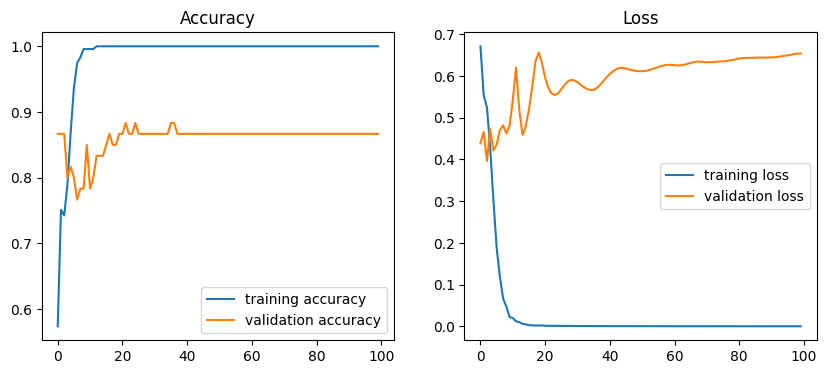

```python
# Build a simple RNN model for binary classification
model_simpleRNN = Sequential()
model_simpleRNN.add(Embedding(input_dim=total_words+1, output_dim=100, input_length=max_sequence_length))
model_simpleRNN.add(SimpleRNN(units=128, return_sequences=True))  # First SimpleRNN layer with 128 units
model_simpleRNN.add(Dropout(0.4))  # Adding dropout with a rate of 0.4
model_simpleRNN.add(SimpleRNN(units=64))  # Second SimpleRNN layer with 64 units
model_simpleRNN.add(Dense(1, activation='sigmoid'))

# Compile the model
model_simpleRNN.compile(optimizer='adam', loss='binary_crossentropy', metrics=['accuracy'])

# Print the model summary
model_simpleRNN.summary()

# Fit the model
history_simpleRNN = model_simpleRNN.fit(X_train, y_train, validation_data=(X_test, y_test),
                    epochs=100, batch_size=128, verbose=1)

# Final evaluation of the model
scores = model_simpleRNN.evaluate(X_test, y_test, verbose=0)
accuracy = scores[1]
error_rate = (1 - accuracy) * 100

print("RNN Model Accuracy: {:.2f}%".format(accuracy * 100))
print("RNN Model Error Rate: {:.2f}%".format(error_rate))

# Plot training and validation accuracy
plt.figure(figsize=(10, 4))
plt.subplot(1, 2, 1)
plt.plot(history_simpleRNN.history['accuracy'], label='training accuracy')
plt.plot(history_simpleRNN.history['val_accuracy'], label='validation accuracy')
plt.legend()
plt.title('Accuracy')

# Plot training and validation loss
plt.subplot(1, 2, 2)
plt.plot(history_simpleRNN.history['loss'], label='training loss')
plt.plot(history_simpleRNN.history['val_loss'], label='validation loss')
plt.legend()
plt.title('Loss')

plt.show()
```

### LSTM (Long Short-Term Memory)

Long Short-Term Memory (LSTM) is a type of recurrent neural network (RNN) architecture designed to overcome the limitations of traditional RNNs, such as the vanishing gradient problem, which hampers their ability to learn long-term dependencies in sequential data. LSTMs are widely used for various tasks involving time series and sequential data due to their ability to effectively capture long-range dependencies.

Advantages of LSTM

- Capturing Long-Term Dependencies:
  - LSTMs are specifically designed to address the vanishing gradient problem, allowing them to learn dependencies over longer time spans more effectively than traditional RNNs.
- Handling Complex Patterns:
  - LSTMs can capture more complex temporal patterns and dependencies, making them suitable for tasks like natural language processing, speech recognition, and time series forecasting.
- Robust Memory Management:
  - The gating mechanism in LSTMs helps in managing the flow of information, ensuring relevant information is retained over long sequences while irrelevant information is discarded.
- Adaptability:
  - LSTMs can adapt to varying lengths of sequences, making them flexible for different types of sequential data.

Disadvantages of LSTM

- Complexity:
  - LSTMs are more complex than SimpleRNNs, with more parameters and gates to manage. This complexity can lead to longer training times and increased computational requirements.
- Computationally Intensive:
  - Due to the additional gates and parameters, LSTMs require more computational resources and can be slower to train compared to simpler models.
- Overfitting:
  - The higher number of parameters in LSTMs can lead to overfitting, especially on smaller datasets. Regularization techniques and careful tuning of hyperparameters are often necessary to mitigate this.
- Hyperparameter Sensitivity:
  - LSTMs require careful tuning of hyperparameters such as learning rate, number of layers, and the number of units in each layer. Improper tuning can significantly impact performance.

Applications of LSTM

- LSTMs are widely used in a variety of applications where understanding and predicting sequential patterns is crucial:
- Natural Language Processing (NLP):
  - Tasks such as language modeling, machine translation, text generation, and sentiment analysis benefit greatly from LSTM's ability to capture long-term dependencies in text.
- Speech Recognition:
  - LSTMs can model the temporal dynamics of speech, improving the accuracy of speech recognition systems.
- Time Series Prediction:
  - In fields like finance and meteorology, LSTMs are used for forecasting future values based on historical data.
- Video Analysis: - LSTMs can process video frames as sequences, enabling applications like action recognition and video captioning.
- Music Generation:
  - LSTMs can generate music by learning patterns in sequences of musical notes.

In summary, LSTMs provide a powerful tool for handling sequential data and capturing long-term dependencies, addressing the shortcomings of traditional RNNs. Despite their complexity and computational demands, their effectiveness in a wide range of applications makes them a popular choice in many deep learning tasks.

```
Model: "sequential_19"
_________________________________________________________________
 Layer (type)                Output Shape              Param #
=================================================================
 embedding_19 (Embedding)    (None, 57, 100)           73800

 lstm_12 (LSTM)              (None, 57, 128)           117248

 dropout_19 (Dropout)        (None, 57, 128)           0

 lstm_13 (LSTM)              (None, 64)                49408

 dense_19 (Dense)            (None, 1)                 65

=================================================================
Total params: 240,521
Trainable params: 240,521
Non-trainable params: 0
_________________________________________________________________
RNN Model Accuracy: 90.00%
RNN Model Error Rate: 10.00%
```

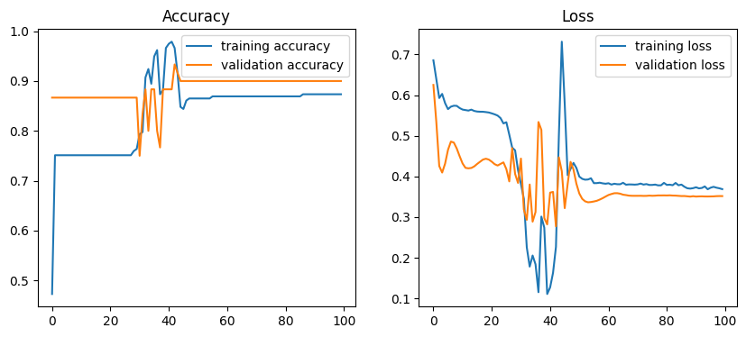

```python
# Define the LSTM model
model_LSTM = Sequential()
model_LSTM.add(Embedding(input_dim=total_words+1, output_dim=100, input_length=max_sequence_length))
model_LSTM.add(LSTM(units=128, return_sequences=True))  # First LSTM layer with 128 units
model_LSTM.add(Dropout(0.4))  # Adding dropout with a rate of 0.4
model_LSTM.add(LSTM(units=64))  # Second LSTM layer with 64 units
model_LSTM.add(Dense(1, activation='sigmoid'))

# Compile the model
model_LSTM.compile(optimizer='adam', loss='binary_crossentropy', metrics=['accuracy'])

# Print the model summary
model_LSTM.summary()

# Fit the model
history_LSTM = model_LSTM.fit(X_train, y_train, validation_data=(X_test, y_test),
                    epochs=100, batch_size=128, verbose=1)

# Final evaluation of the model
scores = model_LSTM.evaluate(X_test, y_test, verbose=0)
accuracy = scores[1]
error_rate = (1 - accuracy) * 100

print("RNN Model Accuracy: {:.2f}%".format(accuracy * 100))
print("RNN Model Error Rate: {:.2f}%".format(error_rate))

# Plot training and validation accuracy
plt.figure(figsize=(10, 4))
plt.subplot(1, 2, 1)
plt.plot(history_LSTM.history['accuracy'], label='training accuracy')
plt.plot(history_LSTM.history['val_accuracy'], label='validation accuracy')
plt.legend()
plt.title('Accuracy')

# Plot training and validation loss
plt.subplot(1, 2, 2)
plt.plot(history_LSTM.history['loss'], label='training loss')
plt.plot(history_LSTM.history['val_loss'], label='validation loss')
plt.legend()
plt.title('Loss')

plt.show()
```

### GRU (Gated Recurrent Unit)

The Gated Recurrent Unit (GRU) is a type of recurrent neural network (RNN) architecture designed to handle sequential data and address some of the limitations of traditional RNNs, such as the vanishing gradient problem. GRUs are similar to Long Short-Term Memory (LSTM) networks but are simpler in design, making them a popular choice for many sequence modeling tasks.

Key Features of GRU:

- Gating Mechanisms: GRUs use gating mechanisms to control the flow of information within the unit. These gates help the network decide when to update the hidden state and when to reset it, which helps mitigate the vanishing gradient problem and enables the network to capture long-term dependencies.
- Simpler Architecture than LSTM: While LSTMs use three gates (input, output, and forget gates), GRUs use only two gates: the update gate and the reset gate. This makes GRUs computationally more efficient and faster to train compared to LSTMs.

Advantages of GRU:

- Mitigation of Vanishing Gradient Problem:
  - GRUs effectively address the vanishing gradient problem through their gating mechanisms, allowing them to capture long-term dependencies in sequences better than traditional RNNs.
- Computational Efficiency:
  - GRUs are generally more computationally efficient than LSTMs due to their simpler architecture. They require fewer parameters and less memory, which can lead to faster training and inference times.
- Performance:
  - Despite their simpler design, GRUs often perform comparably to LSTMs on many tasks, making them a robust choice for a variety of sequence modeling problems.
- Ease of Implementation:
  - The simpler architecture of GRUs can make them easier to implement and tune compared to LSTMs, especially in cases where computational resources are limited.

Disadvantages of GRU:

- Less Expressive Power:
  - While GRUs are simpler and often perform well, they may be less expressive than LSTMs in certain tasks. The additional gate in LSTMs can sometimes provide more nuanced control over the learning process, which can be beneficial for particularly complex tasks.
- Task Specificity:
  - The performance difference between GRUs and LSTMs can vary depending on the specific task and dataset. For some tasks, the additional complexity of LSTMs might lead to better performance.

Conclusion:

GRUs offer a good balance between complexity and performance, making them a popular choice for many sequence modeling tasks. Their ability to handle long-term dependencies, coupled with their computational efficiency, makes them particularly useful for a wide range of applications, from natural language processing to time series forecasting. However, the choice between GRUs and LSTMs should be based on the specific requirements of the task at hand.

```
Model: "sequential_20"
_________________________________________________________________
 Layer (type)                Output Shape              Param #
=================================================================
 embedding_20 (Embedding)    (None, 57, 100)           73800

 gru_12 (GRU)                (None, 57, 128)           88320

 dropout_20 (Dropout)        (None, 57, 128)           0

 gru_13 (GRU)                (None, 64)                37248

 dense_20 (Dense)            (None, 1)                 65

=================================================================
Total params: 199,433
Trainable params: 199,433
Non-trainable params: 0
_________________________________________________________________
RNN Model Accuracy: 91.67%
RNN Model Error Rate: 8.33%
```

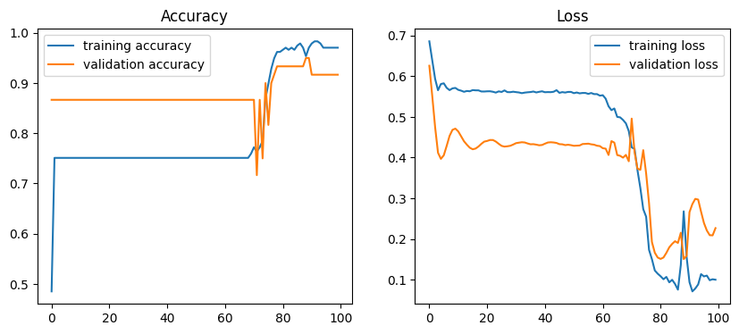

```python
# Define the GRU model
model_GRU = Sequential()
model_GRU.add(Embedding(input_dim=total_words+1, output_dim=100, input_length=max_sequence_length))
model_GRU.add(GRU(units=128, return_sequences=True))  # First GRU layer with 128 units
model_GRU.add(Dropout(0.4))  # Adding dropout with a rate of 0.4
model_GRU.add(GRU(units=64))  # Second GRU layer with 64 units
model_GRU.add(Dense(1, activation='sigmoid'))

# Compile the model
model_GRU.compile(optimizer='adam', loss='binary_crossentropy', metrics=['accuracy'])

# Print the model summary
model_GRU.summary()

# Fit the model
history_GRU = model_GRU.fit(X_train, y_train, validation_data=(X_test, y_test),
                     epochs=100, batch_size=128, verbose=1)

# Final evaluation of the model
scores = model_GRU.evaluate(X_test, y_test, verbose=0)
accuracy = scores[1]
error_rate = (1 - accuracy) * 100

print("RNN Model Accuracy: {:.2f}%".format(accuracy * 100))
print("RNN Model Error Rate: {:.2f}%".format(error_rate))

# Plot training and validation accuracy
plt.figure(figsize=(10, 4))
plt.subplot(1, 2, 1)
plt.plot(history_GRU.history['accuracy'], label='training accuracy')
plt.plot(history_GRU.history['val_accuracy'], label='validation accuracy')
plt.legend()
plt.title('Accuracy')

# Plot training and validation loss
plt.subplot(1, 2, 2)
plt.plot(history_GRU.history['loss'], label='training loss')
plt.plot(history_GRU.history['val_loss'], label='validation loss')
plt.legend()
plt.title('Loss')

plt.show()
```

### Bi-Directional RNN (SimpleRNN/LSTM/GRU)

A Bi-Directional Recurrent Neural Network (Bi-Directional RNN or BiRNN) is an extension of the traditional RNN architecture that aims to improve the performance of sequence modeling tasks by processing data in both forward and backward directions. This allows the network to have a more comprehensive understanding of the context for each element in the sequence.

Key Features of Bi-Directional RNN:

- Forward and Backward Passes: In a BiRNN, two RNNs are employed—one processes the sequence from start to end (forward RNN), and the other processes it from end to start (backward RNN). The hidden states from both RNNs are then concatenated or otherwise combined to produce the final output.
- Contextual Understanding: By considering both past and future context for each element in the sequence, BiRNNs can capture dependencies that might be missed when processing the sequence in only one direction.

Advantages of Bi-Directional RNN:

- Improved Context Understanding:
  - By processing the sequence in both directions, BiRNNs can use information from both the past and future, leading to better performance on tasks where context from both directions is important.
- Enhanced Performance on Certain Tasks:
  - BiRNNs are particularly effective for tasks like speech recognition, machine translation, and natural language understanding, where understanding the full context around each word or phoneme is crucial.
- Better Handling of Ambiguities:
  - BiRNNs can disambiguate situations where context from both directions can provide clearer understanding, such as resolving homophones in speech or polysemous words in text.

Disadvantages of Bi-Directional RNN:

- Increased Computational Complexity:
  - BiRNNs require running two RNNs simultaneously, which increases the computational requirements in terms of both memory and processing power. This can lead to longer training and inference times.
- Potential for Overfitting:
  - The increased model capacity due to the additional parameters in the backward layer can lead to overfitting, especially if the training data is not sufficiently large or diverse.
- Implementation Complexity:
  - Implementing BiRNNs can be more complex compared to unidirectional RNNs, particularly when dealing with variable-length sequences and ensuring efficient concatenation of forward and backward outputs.

Applications of Bi-Directional RNN:

- Speech Recognition: BiRNNs can improve the accuracy of recognizing words in spoken language by using context from both past and future phonemes.
- Machine Translation: BiRNNs enhance the ability to translate sentences by considering the full context of a sentence in both source and target languages.
- Text Summarization: In text summarization, understanding the entire context of the document can lead to better summarization outputs.
- Named Entity Recognition (NER): BiRNNs are effective in identifying named entities in text by considering surrounding words in both directions.

Conclusion:

Bi-Directional RNNs provide a powerful extension to traditional RNNs by enabling the processing of sequences in both directions. This capability enhances the model's ability to understand context, making BiRNNs particularly useful for a range of sequence modeling tasks that benefit from comprehensive contextual information. However, the increased computational complexity and potential for overfitting are important considerations when deciding to use BiRNNs for a specific application.

### Bi-directional SimpleRnn

```
Model: "sequential_21"
_________________________________________________________________
 Layer (type)                Output Shape              Param #
=================================================================
 embedding_21 (Embedding)    (None, 57, 100)           73800

 bidirectional_18 (Bidirecti  (None, 57, 256)          58624
 onal)

 dropout_21 (Dropout)        (None, 57, 256)           0

 bidirectional_19 (Bidirecti  (None, 128)              41088
 onal)

 dense_21 (Dense)            (None, 1)                 129

=================================================================
Total params: 173,641
Trainable params: 173,641
Non-trainable params: 0
_________________________________________________________________
RNN Model Accuracy: 86.67%
RNN Model Error Rate: 13.33%
```

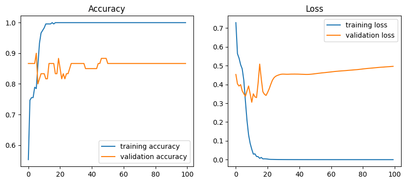

```python
# Define the Bidirectional RNN model
model_biRNN = Sequential()
model_biRNN.add(Embedding(input_dim=total_words+1, output_dim=100, input_length=max_sequence_length))
model_biRNN.add(Bidirectional(SimpleRNN(units=128, return_sequences=True)))  # Bidirectional SimpleRNN layer with 128 units
model_biRNN.add(Dropout(0.4))  # Adding dropout with a rate of 0.4
model_biRNN.add(Bidirectional(SimpleRNN(units=64)))  # Bidirectional SimpleRNN layer with 64 units
model_biRNN.add(Dense(1, activation='sigmoid'))

# Compile the model
model_biRNN.compile(optimizer='adam', loss='binary_crossentropy', metrics=['accuracy'])

# Print the model summary
model_biRNN.summary()

# Fit the model using the early stopping callback
history_biRNN = model_biRNN.fit(X_train, y_train, validation_data=(X_test, y_test),
                    epochs=100, batch_size=128, verbose=1)

# Final evaluation of the model
scores = model_biRNN.evaluate(X_test, y_test, verbose=0)
accuracy = scores[1]
error_rate = (1 - accuracy) * 100

print("RNN Model Accuracy: {:.2f}%".format(accuracy * 100))
print("RNN Model Error Rate: {:.2f}%".format(error_rate))

# Plot training and validation accuracy
plt.figure(figsize=(10, 4))
plt.subplot(1, 2, 1)
plt.plot(history_biRNN.history['accuracy'], label='training accuracy')
plt.plot(history_biRNN.history['val_accuracy'], label='validation accuracy')
plt.legend()
plt.title('Accuracy')

# Plot training and validation loss
plt.subplot(1, 2, 2)
plt.plot(history_biRNN.history['loss'], label='training loss')
plt.plot(history_biRNN.history['val_loss'], label='validation loss')
plt.legend()
plt.title('Loss')

plt.show()
```

### Bi-directional LSTM

```
Model: "sequential_33"
_________________________________________________________________
 Layer (type)                Output Shape              Param #
=================================================================
 embedding_33 (Embedding)    (None, 57, 100)           73800

 bidirectional_36 (Bidirecti  (None, 57, 256)          234496
 onal)

 dropout_33 (Dropout)        (None, 57, 256)           0

 bidirectional_37 (Bidirecti  (None, 128)              164352
 onal)

 dense_33 (Dense)            (None, 1)                 129

=================================================================
Total params: 472,777
Trainable params: 472,777
Non-trainable params: 0
_________________________________________________________________
BiLSTM Model Accuracy: 93.33%
BiLSTM Model Error Rate: 6.67%
```

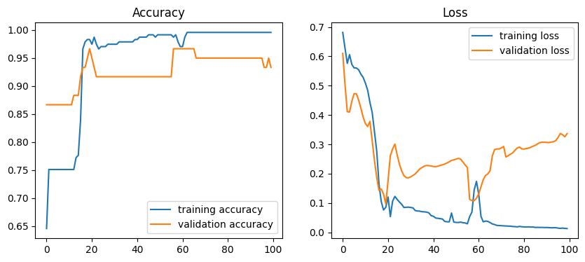

```python
# Define the Bidirectional LSTM model
model_biLSTM = Sequential()
model_biLSTM.add(Embedding(input_dim=total_words+1, output_dim=100, input_length=max_sequence_length))
model_biLSTM.add(Bidirectional(LSTM(units=128, return_sequences=True)))  # Bidirectional LSTM layer with 128 units
model_biLSTM.add(Dropout(0.4))  # Adding dropout with a rate of 0.4
model_biLSTM.add(Bidirectional(LSTM(units=64)))  # Bidirectional LSTM layer with 64 units
model_biLSTM.add(Dense(1, activation='sigmoid'))

# Compile the model
model_biLSTM.compile(optimizer='adam', loss='binary_crossentropy', metrics=['accuracy'])

# Print the model summary
model_biLSTM.summary()

# Fit the model using the early stopping callback
history_biLSTM = model_biLSTM.fit(X_train, y_train, validation_data=(X_test, y_test),
                    epochs=100, batch_size=128, verbose=1)

# Final evaluation of the model
scores = model_biLSTM.evaluate(X_test, y_test, verbose=0)
accuracy = scores[1]
error_rate = (1 - accuracy) * 100

print("BiLSTM Model Accuracy: {:.2f}%".format(accuracy * 100))
print("BiLSTM Model Error Rate: {:.2f}%".format(error_rate))

# Plot training and validation accuracy
plt.figure(figsize=(10, 4))
plt.subplot(1, 2, 1)
plt.plot(history_biLSTM.history['accuracy'], label='training accuracy')
plt.plot(history_biLSTM.history['val_accuracy'], label='validation accuracy')
plt.legend()
plt.title('Accuracy')

# Plot training and validation loss
plt.subplot(1, 2, 2)
plt.plot(history_biLSTM.history['loss'], label='training loss')
plt.plot(history_biLSTM.history['val_loss'], label='validation loss')
plt.legend()
plt.title('Loss')

plt.show()
```

### Bi-directional GRU

```
Model: "sequential_32"
_________________________________________________________________
 Layer (type)                Output Shape              Param #
=================================================================
 embedding_32 (Embedding)    (None, 57, 100)           73800

 bidirectional_34 (Bidirecti  (None, 57, 256)          176640
 onal)

 dropout_32 (Dropout)        (None, 57, 256)           0

 bidirectional_35 (Bidirecti  (None, 128)              123648
 onal)

 dense_32 (Dense)            (None, 1)                 129

=================================================================
Total params: 374,217
Trainable params: 374,217
Non-trainable params: 0
_________________________________________________________________
BiGRU Model Accuracy: 93.33%
BiGRU Model Error Rate: 6.67%
```

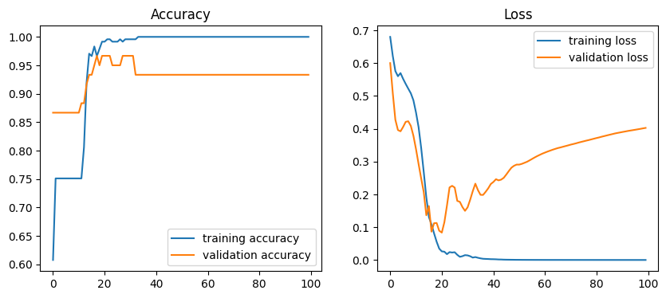

```python
# Define the Bidirectional GRU model
model_biGRU = Sequential()
model_biGRU.add(Embedding(input_dim=total_words+1, output_dim=100, input_length=max_sequence_length))
model_biGRU.add(Bidirectional(GRU(units=128, return_sequences=True)))  # Bidirectional GRU layer with 128 units
model_biGRU.add(Dropout(0.4))  # Adding dropout with a rate of 0.4
model_biGRU.add(Bidirectional(GRU(units=64)))  # Bidirectional GRU layer with 64 units
model_biGRU.add(Dense(1, activation='sigmoid'))

# Compile the model
model_biGRU.compile(optimizer='adam', loss='binary_crossentropy', metrics=['accuracy'])

# Print the model summary
model_biGRU.summary()

# Fit the model using the early stopping callback
history_biGRU = model_biGRU.fit(X_train, y_train, validation_data=(X_test, y_test),
                    epochs=100, batch_size=128, verbose=1)

# Final evaluation of the model
scores = model_biGRU.evaluate(X_test, y_test, verbose=0)
accuracy = scores[1]
error_rate = (1 - accuracy) * 100

print("BiGRU Model Accuracy: {:.2f}%".format(accuracy * 100))
print("BiGRU Model Error Rate: {:.2f}%".format(error_rate))

# Plot training and validation accuracy
plt.figure(figsize=(10, 4))
plt.subplot(1, 2, 1)
plt.plot(history_biGRU.history['accuracy'], label='training accuracy')
plt.plot(history_biGRU.history['val_accuracy'], label='validation accuracy')
plt.legend()
plt.title('Accuracy')

# Plot training and validation loss
plt.subplot(1, 2, 2)
plt.plot(history_biGRU.history['loss'], label='training loss')
plt.plot(history_biGRU.history['val_loss'], label='validation loss')
plt.legend()
plt.title('Loss')

plt.show()
```

## Deciding which model to use after looking at base model

Lets summarize each individual model pros and cons in terms of classification of movie reviews:

SimpleRNN:

- Pros: Simple to understand and implement.
- Cons: Suffers from the vanishing gradient problem, making it difficult to learn long-term dependencies. This can be a significant drawback for processing long movie reviews where context from earlier in the review can influence the overall sentiment.
- Suitability: Not recommended for movie review classification due to its limited ability to handle long sequences and complex dependencies.

LSTM (Long Short-Term Memory) RNN:

- Pros: Specifically designed to address the vanishing gradient problem. LSTMs can learn long-term dependencies and maintain information over long sequences, making them highly effective for text data.
- Cons: More complex and computationally intensive compared to SimpleRNNs.
- Suitability: Highly suitable for movie review classification. LSTMs are a strong choice for handling the nuances and complexities of natural language in movie reviews.

GRU (Gated Recurrent Unit) RNN:

- Pros: Similar to LSTMs but with a simpler architecture. GRUs are computationally more efficient and can still capture long-term dependencies effectively.
- Cons: Slightly less expressive than LSTMs but often performs comparably in practice.
- Suitability: Highly suitable for movie review classification. GRUs offer a good balance between performance and computational efficiency.

Bi-Directional RNN:

- Pros: Processes input data in both forward and backward directions, allowing the model to consider both past and future context. This can significantly enhance understanding in tasks where context from both directions is beneficial.
- Cons: More computationally intensive and requires more memory. The bidirectional processing means that you need the entire sequence beforehand, which might introduce latency.
- Suitability: Highly suitable for movie review classification. Bi-Directional RNNs can capture comprehensive context, making them very effective for understanding sentiment in movie reviews.

Furthermore looking at the accuracies of each base model and the graphs:

GRU (Gated Recurrent Unit) RNN:

- RNN Model Accuracy: 91.67%
- RNN Model Error Rate: 8.33%
- Training Accuracy: Stagnent before experiencing flucations and an increase to stablise around 0.95
- Validation Accuracy: Stagnent before experiencing flucations and an increase to a stablisation of around 0.90
- Training Loss: Flucations to around 0.1
- Validation Loss: Flucations to around 0.25
- Small overfitting

Bi-Directional SimpleRNN:

- RNN Model Accuracy: 86.67%
- RNN Model Error Rate: 13.33%
- Training Accuracy: Increases to around 1.0 and stablises
- Validation Accuracy: Flucates to a stablalisation of around 0.85
- Training Loss: Decreases before stablising at a low value
- Validation Loss: Flucates before having a trend of slow increase around 0.45
- Large overfitting

Bi-Directional LSTM:

- RNN Model Accuracy: 93.33%
- RNN Model Error Rate: 6.67%
- Training Accuracy: Increases before stablising at around 1.0
- Validation Accuracy: Increases and flucates before stablising at around 0.93
- Training Loss: Decreases before stablising at a low value
- Validation Loss: Decreases and flucates before folowing a trend of slight increase to a high value

Summary: For movie review classification, LSTM RNN, GRU RNN, and Bi-Directional RNN are all strong candidates.

- LSTM RNN: Prioritize capturing complex dependencies and are willing to handle the additional computational complexity.
- GRU RNN: Good balance between computational efficiency and performance.
- Bi-Directional RNN: Capturing context from both past and future is critical for improving classification accuracy and you can afford the additional computational resources.

Decision:

- I have chosen to go with Bi-directional RNN using LSTM as its algorithm.
- This is because the model has a high model accuracy of 93.33% and the stated pros and cons fit my purpose well (LSTMs can learn long-term dependencies and maintain information over long sequences, making them highly effective for text data and Bi-Directional RNNs can capture comprehensive context, making them very effective for understanding sentiment in movie reviews.)
- Did not decide on GRU as it is less expressive than other learning models.

#### Model improvement (Hyperparameter tuning)

```python
def create_model(units=128, dropout_rate=0.4, learning_rate=0.001):
    model = Sequential()
    model.add(Embedding(input_dim=total_words+1, output_dim=100, input_length=max_sequence_length))
    model.add(Bidirectional(LSTM(units=units, return_sequences=True)))
    model.add(Dropout(dropout_rate))
    model.add(Bidirectional(LSTM(units=int(units/2))))
    model.add(Dense(1, activation='sigmoid'))

    optimizer = Adam(lr=learning_rate)
    model.compile(optimizer=optimizer, loss='binary_crossentropy', metrics=['accuracy'])

    return model

param_grid = {
    'units': [64, 128, 256],
    'dropout_rate': [0.2, 0.4, 0.6],
    'learning_rate': [0.001, 0.01, 0.1]
}

model = KerasClassifier(build_fn=create_model, epochs=100, batch_size=128, verbose=0)

random_search = RandomizedSearchCV(estimator=model, param_distributions=param_grid, n_iter=10, cv=3, verbose=2)
random_search.fit(X_train, y_train)

print("Best Parameters: ", random_search.best_params_)
print("Best Accuracy: ", random_search.best_score_)
```

```
Fitting 3 folds for each of 10 candidates, totalling 30 fits
[CV] END ....dropout_rate=0.4, learning_rate=0.01, units=256; total time=  16.9s
[CV] END ....dropout_rate=0.4, learning_rate=0.01, units=256; total time=  12.8s
[CV] END ....dropout_rate=0.4, learning_rate=0.01, units=256; total time=  13.2s
[CV] END ....dropout_rate=0.6, learning_rate=0.01, units=256; total time=  13.3s
WARNING:tensorflow:5 out of the last 5 calls to <function Model.make_test_function.<locals>.test_function at 0x00000226DE4A7C10> triggered tf.function retracing. Tracing is expensive and the excessive number of tracings could be due to (1) creating @tf.function repeatedly in a loop, (2) passing tens…
[CV] END ....dropout_rate=0.6, learning_rate=0.01, units=256; total time=  13.3s
WARNING:tensorflow:6 out of the last 6 calls to <function Model.make_test_function.<locals>.test_function at 0x00000227E79B8E50> triggered tf.function retracing. Tracing is expensive and the excessive number of tracings could be due to (1) creating @tf.function repeatedly in a loop, (2) passing tens…
[CV] END ....dropout_rate=0.6, learning_rate=0.01, units=256; total time=  13.7s
[CV] END .....dropout_rate=0.2, learning_rate=0.1, units=256; total time=  13.2s
[CV] END .....dropout_rate=0.2, learning_rate=0.1, units=256; total time=  13.6s
[CV] END .....dropout_rate=0.2, learning_rate=0.1, units=256; total time=  13.2s
[CV] END .....dropout_rate=0.4, learning_rate=0.01, units=64; total time=   8.6s
[CV] END .....dropout_rate=0.4, learning_rate=0.01, units=64; total time=   8.2s
[CV] END .....dropout_rate=0.4, learning_rate=0.01, units=64; total time=   8.7s
[CV] END ...dropout_rate=0.4, learning_rate=0.001, units=256; total time=  13.3s
[CV] END ...dropout_rate=0.4, learning_rate=0.001, units=256; total time=  13.7s
[CV] END ...dropout_rate=0.4, learning_rate=0.001, units=256; total time=  13.5s
[CV] END .....dropout_rate=0.2, learning_rate=0.1, units=128; total time=   9.9s
[CV] END .....dropout_rate=0.2, learning_rate=0.1, units=128; total time=   9.7s
[CV] END .....dropout_rate=0.2, learning_rate=0.1, units=128; total time=  22.7s
[CV] END ....dropout_rate=0.4, learning_rate=0.01, units=128; total time=  19.8s
[CV] END ....dropout_rate=0.4, learning_rate=0.01, units=128; total time=  14.3s
[CV] END ....dropout_rate=0.4, learning_rate=0.01, units=128; total time=   9.1s
[CV] END ......dropout_rate=0.2, learning_rate=0.1, units=64; total time=   8.7s
[CV] END ......dropout_rate=0.2, learning_rate=0.1, units=64; total time=   8.1s
[CV] END ......dropout_rate=0.2, learning_rate=0.1, units=64; total time=   8.4s
[CV] END .....dropout_rate=0.4, learning_rate=0.1, units=128; total time=   9.2s
[CV] END .....dropout_rate=0.4, learning_rate=0.1, units=128; total time=   9.4s
[CV] END .....dropout_rate=0.4, learning_rate=0.1, units=128; total time=   9.1s
[CV] END .....dropout_rate=0.6, learning_rate=0.1, units=128; total time=   9.6s
[CV] END .....dropout_rate=0.6, learning_rate=0.1, units=128; total time=   9.4s
[CV] END .....dropout_rate=0.6, learning_rate=0.1, units=128; total time=   9.4s
Best Parameters:  {'units': 256, 'learning_rate': 0.001, 'dropout_rate': 0.4}
Best Accuracy:  0.8902953465779623
```

Parameter explainations:

- units: This parameter determines the dimensionality of the output space of the LSTM layers. It represents the number of units or neurons in each LSTM layer. dropout_rate: Dropout is a regularization technique used to prevent overfitting. This parameter specifies the dropout rate, which is the fraction of input units to drop during training.
- learning_rate: Learning rate controls the step size during optimization. It determines how much the model parameters are updated during training in response to the estimated error. Higher learning rates can lead to faster convergence but may risk overshooting the optimal solution. Randomized Search Parameters:
- n_iter: This parameter specifies the number of parameter settings that are sampled from the specified hyperparameter distributions. In the script, it's set to 10, meaning that 10 random combinations of hyperparameters will be tried.
- cv: Cross-validation is a technique used to assess how well a model generalizes to an independent dataset. This parameter determines the number of folds in the cross-validation strategy. In the script, it's set to 3, meaning that the data is split into 3 folds for training and validation. verbose: This parameter controls the verbosity of the search process. A higher value results in more detailed output during the search process.

#### Fitting it into the model

```
Best Model Accuracy: 95.00%
Best Model Error Rate: 5.00%
```

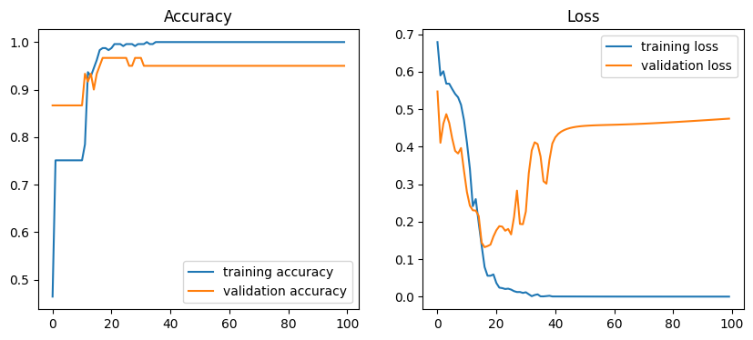

```python
best_model = create_model(units=random_search.best_params_['units'],
                          dropout_rate=random_search.best_params_['dropout_rate'],
                          learning_rate=random_search.best_params_['learning_rate'])
history_best_model = best_model.fit(X_train, y_train, validation_data=(X_test, y_test),
                                    epochs=100, batch_size=128, verbose=1)

scores_best_model = best_model.evaluate(X_test, y_test, verbose=0)
accuracy_best_model = scores_best_model[1]
error_rate_best_model = (1 - accuracy_best_model) * 100

print("Best Model Accuracy: {:.2f}%".format(accuracy_best_model * 100))
print("Best Model Error Rate: {:.2f}%".format(error_rate_best_model))

# Plot training and validation accuracy
plt.figure(figsize=(10, 4))
plt.subplot(1, 2, 1)
plt.plot(history_best_model.history['accuracy'], label='training accuracy')
plt.plot(history_best_model.history['val_accuracy'], label='validation accuracy')
plt.legend()
plt.title('Accuracy')

# Plot training and validation loss
plt.subplot(1, 2, 2)
plt.plot(history_best_model.history['loss'], label='training loss')
plt.plot(history_best_model.history['val_loss'], label='validation loss')
plt.legend()
plt.title('Loss')

plt.show()
```

We have improved the model that we have chosen through hyperparameter tuning. The Bi directional LSTM model has an improved accuracy of 95% and an error rate of 5% error rate. There is a decrease in the overfitting as seen by the smaller difference between training and validation accuracy. There is a larger loss between training and validation loss.

```python
# Save the best model weights
best_model.save_weights('./bi-LSTM_Model_best_weights.h5')
```

## Conclusion

The final model that we would be using for movie review sentiment analysis and prediction would be Bi-directional LSTM model. It has the highest accuracy rate of 95% and the lowest error rate of 5%. If we want to conduct sentiment analysis, we can introduce new unseen movie review sentences and allow the model to predict the sentiment of the review.